# Brent — the global benchmark with a physical overlay

## 3. Events, dashboard, CDF regime label

Portfolio-wide event overlay on the spread series; 4-panel dashboard for a single-screen read; CDF regime classification using 80/95/99 percentiles on pre-2025 M1-M6 (Tight/Stress/Crisis thresholds 1.07 / 1.33 / 1.51 USD/bbl).

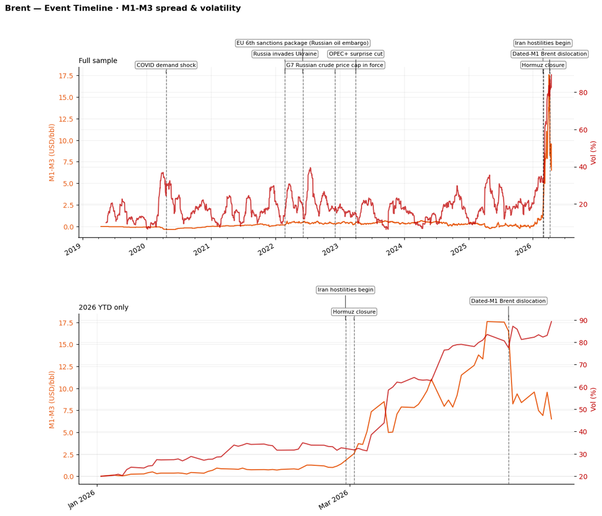

```python
fca.chart_event_timeline();
```

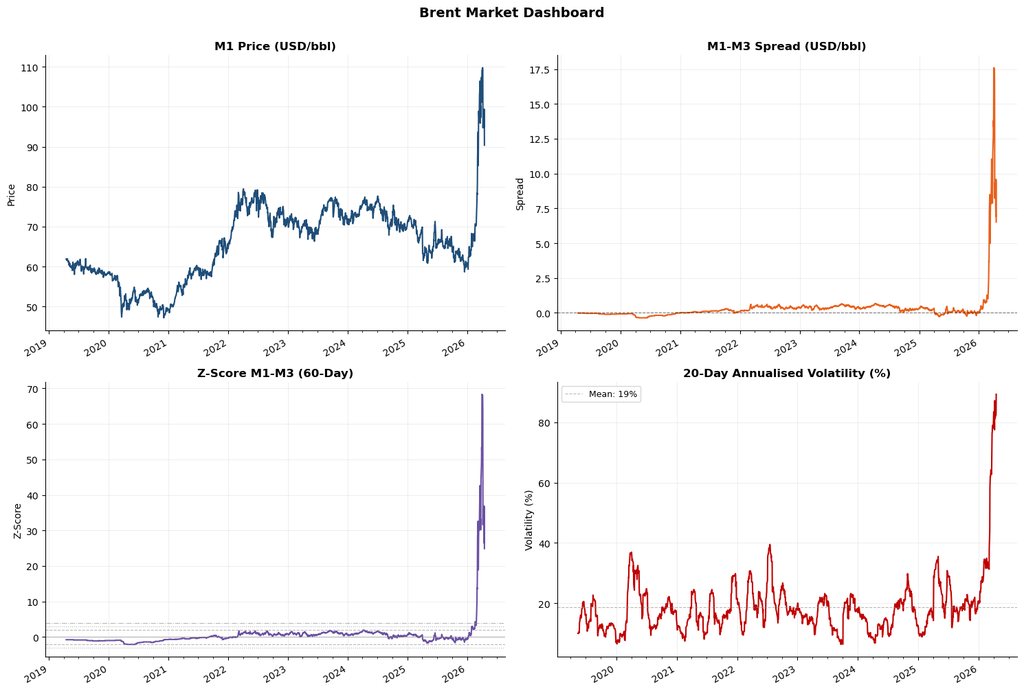

```python
fca.chart_dashboard();
```

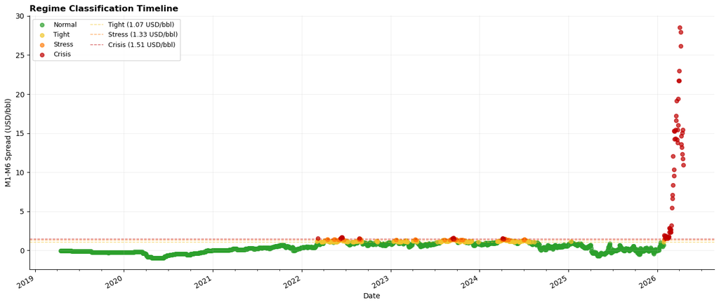

```python
fca.chart_regime();
```

## 4. Dated Brent vs paper M1 — April 2026 event study

**Data window is short.** The Dated assessment file covers only **2026-01-02 → 2026-04-14 (69 days, 3.5 months)** — nothing further back. Treat the chart as an event study around the April 7 dislocation, not a long-run basis analysis. Dated printed 144.42 USD/bbl on 2026-04-07 while Jun-26 futures settled at 109.27 — a ≈ $35 physical-paper gap. That gap is the cash-over-paper basis trade: long physical, short paper swap, bank the premium as paper catches up (the mirror image of the Med Cargo Week-15 products basis trade).

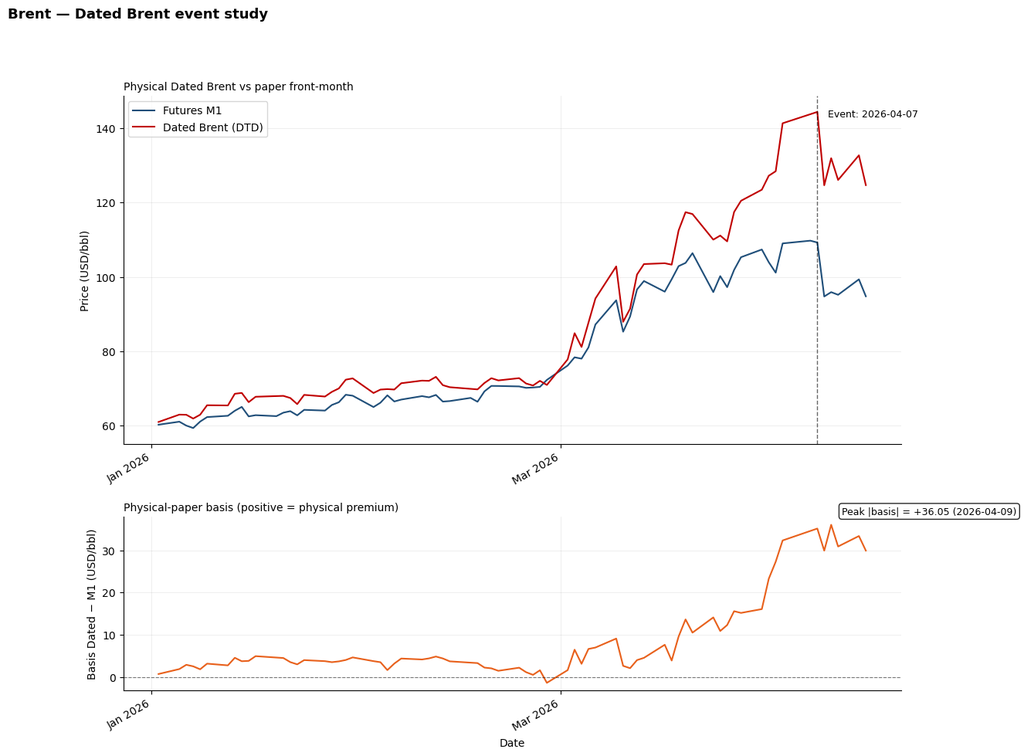

```python
fca.chart_dated_event_study(EVENT_DATE='2026-04-07');
```

## 5. HMM probabilistic regime + next-day forecast

```
HMM means (by state): [ 0.4121642  12.90464468]
HMM std   (by state): [0.61629259 7.06069064]
Transition matrix:
[[9.99434043e-01 5.65957128e-04]
 [1.54333383e-18 1.00000000e+00]]
IS  P(crisis)>0.5 days: 0/1476 (0.0%)
OOS P(crisis)>0.5 days: 42/333 (12.6%)
```

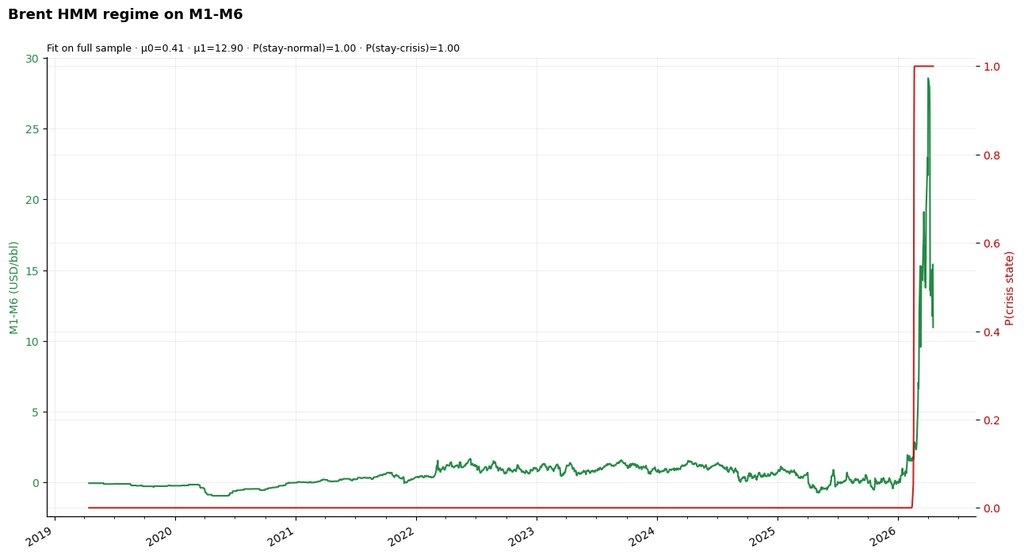

```python
fca.chart_hmm_regime(SPREAD='M1_M6', N_STATES=2);
```